# Data Handling: Import, Cleaning and Visualisation

Lecture 6:  
Updates on exam and group project

Dr. Aurélien Sallin

2026-10-22

[figure not shown]

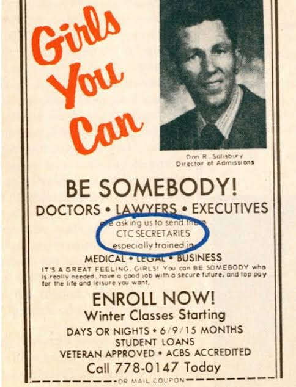

## The project “Women at work” is online

- Have fun
- First contact with `R`
- Use APIs like a pro
- Use LLMs to help you solve it
- Split tasks within the group
- Only questions asked on the **forum** in Canvas will be answered
- Deadline submission first part: **November 6th, 2026, 23:59**

## Exam

- The *mock exam* is online 💣. The mock exam is longer (90mn) than the final exam this year (60mn)
- The exam is similar in spirit and difficulty to the mock exam and to the quizzes.
- Questions on the group project will be asked
- If you attend the course and do the quizzes regularly, you’ll get familiar with the way I like asking questions…
- Goal: you understand the concepts seen in the course and you can read and understand code.
- ❗**You are not asked to write code**.

## What to expect in the exam

#### **True/False questions**, **multiple-choice questions**, and **multiple-correct options**.

- Designed to test your understanding of the material.
- Exactly same style and structure as quizzes and mock exam
- We do not invent wrong function parameters or misspell function names etc to mislead you!

#### Essay questions

- Ask you to explain what you did in the group project and what we covered in the course.
- Can be a piece of code to comment on, a question on the data or on the data pipeline, etc.

## What to expect in the exam

#### How to work your way efficiently through the exam

- Work step-by-step through the code example. What happens in each parenthesis, on each line?
- From the inner part to the outer part, from top to bottom.
- If a code-example question refers to specific functions, you can always assume that the corresponding package is also loaded.